# Example with simulated data

Julien Riou

04/12/2021

## Simulate vaccination coverage

We start by simulating vaccination coverage for a year following a typical vaccination campaign. We consider 5 age groups, and assume that the coverage will be higher in older age groups. We also assume that the number of daily vaccinations starts high and decreases with time, and scale the coverage so that it ends at 95% in the oldest age group.

```r
WEEKS = 1:52
AGE_GROUPS = 1:5
COV_MAX = .95
coveragedata = expand_grid(week=WEEKS, age_group=AGE_GROUPS) %>%
  mutate(coverage=rpois(length(WEEKS)*length(AGE_GROUPS),10*1/week*age_group)) %>%
  group_by(age_group) %>%
  mutate(coverage=cumsum(coverage),
         coverage=age_group*coverage/max(coverage)/max(AGE_GROUPS)*COV_MAX)
```

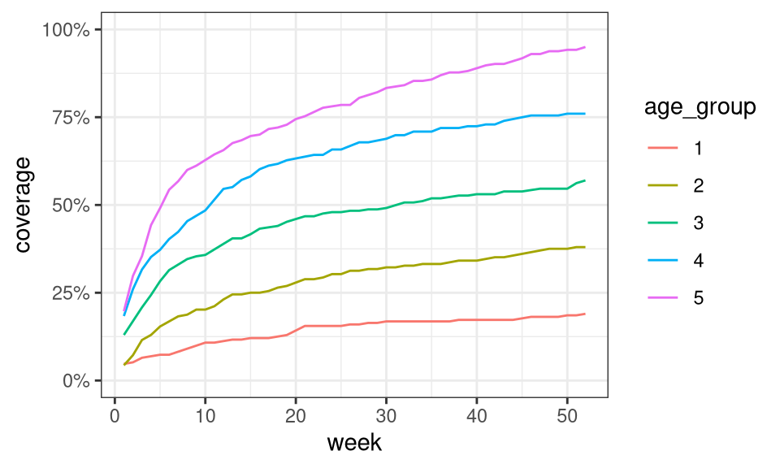

Figure 1. Simulated vaccination coverage in time by age group.

```r
ggplot(coveragedata) +
  geom_line(aes(x=week,y=coverage,colour=factor(age_group))) +
  labs(colour="age_group") +
  scale_y_continuous(labels=scales::percent,limits=c(0,1))
```

## Simulate vaccination status among hospitalized

```r
N = 5000
CHOSEN_RR = 10
```

We simulate typical surveillance data on hospitalized patients. We generate 5000 patients and attribute to each a week of hospitalization and an age group uniformly. Using the coverage data, we link each patient with the vaccination coverage at the corresponding time in the corresponding age group.

```r
survdata = tibble(id=1:N,
                  week=sample(WEEKS,N,replace=TRUE),
                  age_group=sample(AGE_GROUPS,N,replace=TRUE)) %>%
  left_join(coveragedata,by=c("week","age_group"))
```

We now simulate the expected probability that each patient is vaccinated or not depending on (1) vaccination coverage and (2) a relative risk of hospitalization among non-vaccinated compared to vaccinated of 10. For that we use the following equation:
$$\Pr(V|H) = \frac{\Pr(V)}{\Pr(V) + RR\times(1-\Pr(V))}$$
where $\Pr(V|H)$ is the probability of being vaccinated given hospitalization, $\Pr(V)$ is the probability of being vaccinated in the population (i.e. coverage), and $RR$ is relative risk of hospitalization among non-vaccinated compared to vaccinated ($RR=10$). We then draw the actual vaccination status of each individual (`0` for not vaccinated, `1` for vaccinated) from a Bernoulli distribution.

```r
survdata = survdata %>%
  mutate(expected_vacc=coverage/(coverage+CHOSEN_RR*(1-coverage)),
         vacc=rbinom(N,size=1,prob=expected_vacc))
survdata
```

```
## # A tibble: 5,000 × 6
##       id  week age_group coverage expected_vacc  vacc
##    <int> <int>     <int>    <dbl>         <dbl> <int>
##  1     1    15         1   0.121        0.0136      0
##  2     2    14         4   0.571        0.118       0
##  3     3    22         3   0.468        0.0808      0
##  4     4    41         1   0.173        0.0205      0
##  5     5     1         2   0.0433       0.00450     0
##  6     6    26         4   0.668        0.168       0
##  7     7    13         5   0.676        0.173       0
##  8     8    19         4   0.627        0.144       0
##  9     9    10         2   0.202        0.0247      1
## 10    10    45         2   0.361        0.0534      0
## # … with 4,990 more rows
```

Aggregating over time, this results in an increasing trend in the proportion of vaccinated among hospitalized cases.

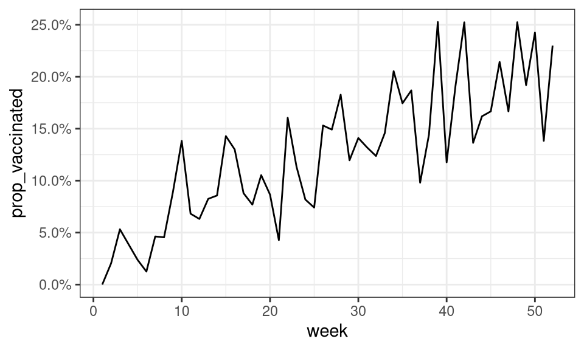

Figure 2. Simulated proportion of vaccinated among hospitalized patients.

```r
survdata %>%
  dplyr::group_by(week) %>%
  dplyr::summarise(prop_vaccinated=mean(vacc)) %>%
  ggplot() +
  geom_line(aes(x=week,y=prop_vaccinated))+
  scale_y_continuous(labels=scales::percent)
```

## Estimate vaccine effectiveness

We can then apply the function `estimate_rr()` and directly estimate the $RR$ of hospitalization among non-vaccinated compared to vaccinated from individual data on the vaccination status of hospitalized patients and the vaccine coverage corresponding to each patient.

```r
EST_RR = estimate_rr(vacc=survdata$vacc, coverage=survdata$coverage)
```

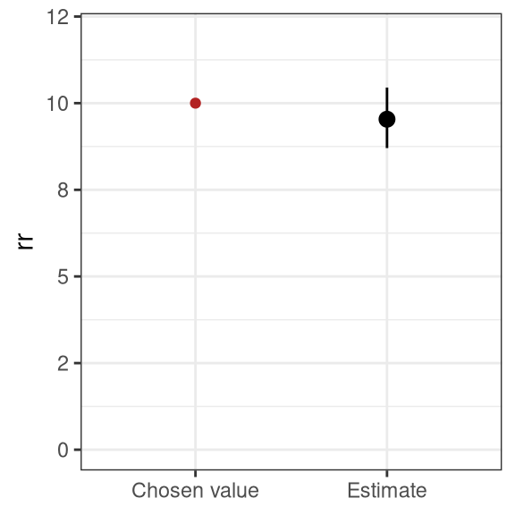

Figure 3. Estimated value of the relative risk of hospitalization among non-vaccinated compared to vaccinated compared to the value chosen to simulate the data.

```r
as_tibble(EST_RR) %>%
  ggplot() +
  geom_pointrange(aes(x="Estimate",y=rr,ymin=rr_lower,ymax=rr_upper)) +
  geom_point(aes(x="Chosen value",y=CHOSEN_RR),colour="firebrick") +
  scale_y_continuous(limits=c(0,CHOSEN_RR*1.2)) +
  labs(x=NULL)
```